# cses_02

version 02

Author

Lior Shvarts

Published

June 25, 2025

- **Loading Packages**

```r
library(tidyverse)
library(gt)
library(gtsummary)
library(janitor)
library(sjPlot)
library(ggcorrplot)
library(labelled)
library(haven)
library(readxl)
library(broom)
library(lme4)
library(ggpubr)
library(ggeffects)
library(lavaan)
Sys.setlocale("LC_ALL","Herbrew")
```

```
[1] ""
```

- **Data**

```r
cses_raw <- read_sav("data/cses5.sav")
```

```r
cses_isr <- cses_raw %>%
  janitor::clean_names() %>%
  filter(e1006_nam == "Israel") %>%
  mutate(understands_politics = recode(e3003, #q03
                                          `7` = 99,
                                          `8` = 99,
                                          `9` = 99),
         understands_politics = na_if(understands_politics, 99),
         compromise_betrayal = recode(e3004_1, # q04a
                                      `7` = 99,
                                      `8` = 99,
                                      `9` = 99),
         compromise_betrayal = na_if(compromise_betrayal, 99),
         compromise_betrayal_reversed = recode(compromise_betrayal,
                                               `5` = 1,
                                               `4` = 2,
                                               `2` = 4,
                                               `1` = 5),
         dont_care_ppl = recode(e3004_2, # q04b
                                `7` = 99,
                                `8` = 99,
                                `9` = 99),
         dont_care_ppl = na_if(dont_care_ppl, 99),
         dont_care_ppl_reversed = recode(dont_care_ppl,
                                         `5` = 1,
                                         `4` = 2,
                                         `2` = 4,
                                         `1` = 5),
         trustworthy = recode(e3004_3, # q04c
                              `7` = 99,
                              `8` = 99,
                              `9` = 99),
         trustworthy = na_if(trustworthy, 99),
         main_problem = recode(e3004_4, # q04d
                               `7` = 99,
                               `8` = 99,
                               `9` = 99),
         main_problem = na_if(main_problem, 99),
         main_problem_reversed = recode(main_problem,
                                        `5` = 1,
                                        `4` = 2,
                                        `2` = 4,
                                        `1` = 5),
         strong_leader = recode(e3004_5, # q05e
                                `7` = 99,
                                `8` = 99,
                                `9` = 99),
         strong_leader = na_if(strong_leader, 99),
         decision_by_ppl = recode(e3004_6, # q04f
                                  `7` = 99,
                                  `8` = 99,
                                  `9` = 99),
         decision_by_ppl = na_if(decision_by_ppl, 99),
         decision_by_ppl_reversed = recode(decision_by_ppl,
                                           `5` = 1,
                                           `4` = 2,
                                           `2` = 4,
                                           `1` = 5),
         care_tycoons = recode(e3004_7, # q04g
                               `7` = 99,
                               `8` = 99,
                               `9` = 99),
         care_tycoons = na_if(care_tycoons, 99),
         care_tycoons_reversed = recode(care_tycoons,
                                        `5` = 1,
                                        `4` = 2,
                                        `2` = 4,
                                        `1` = 5),
         gender = recode(e2002, # e2002
                         `1` = 0, # male
                         `2` = 1, # female
                         .default = 99),
         gender = na_if(gender, 99),
         age = recode(e2001_a, # d02
                      `9999` = 99),
         age = na_if(age, 99),
         education = recode(e2003, # d03
                            `1` = 1, # no bagrut
                            `2` = 1, # no bagrut
                            `3` = 1, # no bagrut
                            `4` = 2, # bagrut
                            `5` = 3, # post high school
                            `6` = 3, # post high school
                            `7` = 4, # B.A.
                            `8` = 5, # M.A.
                            `9` = 6, # Ph.D
                            `96` = 1, # no bagrut
                            .default = 99),
         education = na_if(education, 99),
         household_income = recode(e2011, # d09
                                   `99999997` = 99,
                                   `99999998` = 99,
                                   `99999999` = 99),
         household_income = as.factor(household_income),
         household_income = recode(household_income,
                                   `99` = "unknown"),
         religion = recode(e2013, # d10
                           `1101` = "Christian",
                           `1200` = "Christian",
                           `2000` = "Jewish",
                           `3000` = "Muslim",
                           `3211` = "Druze",
                           .default = "unknown"),
         religion = na_if(religion, "unknown"),
         pop_group = recode(e2016, # a8
                            `1` = 1, # jewish
                            `2` = 0), # arab
         pop_group = na_if(pop_group, 99),
         left_right_scale = recode(e3020, # q18
                                   `95` = 99,
                                   `97` = 99,
                                   `98` = 99),
         left_right_scale = na_if(left_right_scale, 99),
         voting = recode(e3013_lh_pl, # q12lh-b
                         `376001` = "Likud",
                         `376002` = "Blue & White",
                         `376003` = "Joint List",
                         `376004` = "Shas",
                         `376005` = "UTJ",
                         `376006` = "Labor-Gesher-Meretz",
                         `376007` = "Yisrael Beiteinu",
                         `376008` = "Yamina",
                         `376009` = "Otzma Yehudit",
                         .default = "unknown"),
         voting = na_if(voting, "unknown"),
         voting = as.factor(voting),
         gov_performance = recode(e3009,
                                  `6` = 99,
                                  `7` = 99,
                                  `8` = 99,
                                  `9` = 99),
         gov_performance = na_if(gov_performance, 99)) %>%
  filter(pop_group == 1) # jewish
```

# **The Wording of the Questions (in Hebrew)**

- **Q03 / e3003 / understands_politics**

אתה מרגיש שאתה מבין את הנושאים הפוליטיים החשובים ביותר של המדינה (1 - מאוד מסכים; 5 - מאוד לא מסכים)

- **Q04a / e3004_1 / compromise_betrayal**

מה שאנשים מכנים “פשרה” בפוליטיקה זה בעצם בגידה בעקרונות (1 - מאוד מסכים; 5 - מאוד לא מסכים)

- **Q04b / e3004_2 / dont_care_ppl**

לרוב הפוליטיקאים לא אכפת מהעם (1 - מאוד מסכים; 5 - מאוד לא מסכים)

- **Q04c / e3004_3 / trustworthy**

אפשר לתת אמון ברוב הפוליטיקאים (1 - מאוד מסכים; 5 - מאוד לא מסכים)

- **Q04d / e3004_4 / main_problem**

פוליטיקאים הם הבעיה העיקרית של ישראל (1 - מאוד מסכים; 5 - מאוד לא מסכים)

- **Q04e / e3004_5 / strong_leader**

מנהיג חזק הוא טוב לישראל, גם אם אותו מנהיג מכופף את הכללים על מנת להשיג תוצאות (1 - מאוד מסכים; 5 - מאוד לא מסכים)

- **Q04f / e3004_6 / decision_by_ppl**

העם הוא זה שצריך לקבל את ההחלטות המדיניות החשובות ביותר שלנו ולא הפוליטיקאים (1 - מאוד מסכים; 5 - מאוד לא מסכים)

- **Q04g / e3004_7 / care_tycoons**

לרוב הפוליטיקאים אכפת רק מהאינטרסים של בעלי ההון והעוצמה במדינה (1 - מאוד מסכים; 5 - מאוד לא מסכים)

# **Descriptive Statistics**

```r
cses_isr %>%
  mutate(household_income = as.factor(household_income)) %>%
  dplyr::select(understands_politics, compromise_betrayal_reversed, dont_care_ppl_reversed, trustworthy, main_problem_reversed, strong_leader, decision_by_ppl_reversed, care_tycoons_reversed, gov_performance, gender, age, education, household_income, religion, pop_group, left_right_scale) %>%
  gtsummary::tbl_summary(statistic = list(c(age, left_right_scale) ~ "{mean} ({sd})")) %>%
  bold_labels()
```

| **Characteristic** | **N = 1,015**<sup>1</sup> |
| --- | --- |
| INTERNAL EFFICACY |  |
| 1 | 220 (22%) |
| 2 | 313 (31%) |
| 3 | 264 (26%) |
| 4 | 144 (14%) |
| 5 | 60 (6.0%) |
| Unknown | 14 |
| ATTITUDES ABOUT ELITES: COMPROMISE IS SELLING OUT ONE'S PRINCIPLES |  |
| 1 | 196 (20%) |
| 2 | 247 (26%) |
| 3 | 253 (26%) |
| 4 | 171 (18%) |
| 5 | 94 (9.8%) |
| Unknown | 54 |
| ATTITUDES ABOUT ELITES: DO NOT CARE ABOUT THE PEOPLE |  |
| 1 | 90 (9.0%) |
| 2 | 202 (20%) |
| 3 | 252 (25%) |
| 4 | 222 (22%) |
| 5 | 229 (23%) |
| Unknown | 20 |
| ATTITUDES ABOUT ELITES: ARE TRUSTWORTHY |  |
| 1 | 27 (2.7%) |
| 2 | 99 (9.9%) |
| 3 | 273 (27%) |
| 4 | 340 (34%) |
| 5 | 256 (26%) |
| Unknown | 20 |
| ATTITUDES ABOUT ELITES: ARE THE MAIN PROBLEM |  |
| 1 | 167 (17%) |

[output cut: 65 more lines]

<sup>1</sup> n (%); Mean (SD)

# **Correlation table**

```r
cses_isr %>%
  dplyr::select(understands_politics, compromise_betrayal_reversed, dont_care_ppl_reversed, trustworthy, main_problem_reversed, strong_leader, decision_by_ppl_reversed, care_tycoons_reversed, gov_performance, gender, age, education, left_right_scale) %>%
  sjPlot::tab_corr(triangle = "lower",
                   corr.method = "pearson",
                   p.numeric = T,
                   na.deletion = "listwise")
```

|  | INTERNAL EFFICACY | ATTITUDES ABOUT ELITES: COMPROMISE IS SELLING OUT ONE'S PRINCIPLES | ATTITUDES ABOUT ELITES: DO NOT CARE ABOUT THE PEOPLE | ATTITUDES ABOUT ELITES: ARE TRUSTWORTHY | ATTITUDES ABOUT ELITES: ARE THE MAIN PROBLEM | ATTITUDES ABOUT ELITES: STRONG LEADER BENDS THE RULES | ATTITUDES ABOUT ELITES: PEOPLE SHOULD MAKE POLICY DECISIONS | ATTITUDES ABOUT ELITES: RICH AND POWERFUL | GOVERNMENT PERFORMANCE: GENERAL | GENDER | AGE OF RESPONDENT (IN YEARS) | EDUCATION | IDEOLOGY: LEFT-RIGHT - SELF |
| --- | --- | --- | --- | --- | --- | --- | --- | --- | --- | --- | --- | --- | --- |
| INTERNAL EFFICACY |  |  |  |  |  |  |  |  |  |  |  |  |  |
| ATTITUDES ABOUT ELITES: COMPROMISE IS SELLING OUT ONE'S PRINCIPLES | 0.021 (.570) |  |  |  |  |  |  |  |  |  |  |  |  |
| ATTITUDES ABOUT ELITES: DO NOT CARE ABOUT THE PEOPLE | 0.035 (.337) | 0.268 (<.001) |  |  |  |  |  |  |  |  |  |  |  |
| ATTITUDES ABOUT ELITES: ARE TRUSTWORTHY | 0.064 (.078) | 0.043 (.236) | 0.367 (<.001) |  |  |  |  |  |  |  |  |  |  |
| ATTITUDES ABOUT ELITES: ARE THE MAIN PROBLEM | 0.049 (.174) | 0.229 (<.001) | 0.391 (<.001) | 0.228 (<.001) |  |  |  |  |  |  |  |  |  |
| ATTITUDES ABOUT ELITES: STRONG LEADER BENDS THE RULES | -0.050 (.166) | -0.047 (.197) | 0.071 (.049) | 0.140 (<.001) | 0.046 (.206) |  |  |  |  |  |  |  |  |
| ATTITUDES ABOUT ELITES: PEOPLE SHOULD MAKE POLICY DECISIONS | 0.012 (.738) | 0.043 (.239) | 0.117 (.001) | 0.033 (.360) | 0.143 (<.001) | 0.006 (.865) |  |  |  |  |  |  |  |
| ATTITUDES ABOUT ELITES: RICH AND POWERFUL | 0.083 (.021) | 0.215 (<.001) | 0.496 (<.001) | 0.305 (<.001) | 0.399 (<.001) | 0.060 (.099) | 0.162 (<.001) |  |  |  |  |  |  |
| GOVERNMENT PERFORMANCE: GENERAL | 0.010 (.778) | 0.127 (<.001) | 0.271 (<.001) | 0.216 (<.001) | 0.274 (<.001) | 0.381 (<.001) | 0.140 (<.001) | 0.263 (<.001) |  |  |  |  |  |
| GENDER | 0.137 (<.001) | 0.087 (.016) | 0.030 (.410) | 0.073 (.044) | 0.117 (.001) | 0.044 (.228) | -0.019 (.591) | 0.165 (<.001) | 0.001 (.976) |  |  |  |  |
| AGE OF RESPONDENT (IN YEARS) | -0.174 (<.001) | 0.067 (.064) | 0.108 (.003) | 0.043 (.236) | 0.137 (<.001) | 0.071 (.049) | 0.069 (.056) | 0.072 (.045) | 0.102 (.005) | 0.002 (.961) |  |  |  |
| EDUCATION | -0.101 (.005) | -0.102 (.005) | -0.060 (.094) | 0.033 (.356) | -0.131 (<.001) | 0.191 (<.001) | -0.058 (.107) | -0.004 (.921) | 0.112 (.002) | 0.087 (.016) | 0.112 (.002) |  |  |
| IDEOLOGY: LEFT-RIGHT - SELF | 0.103 (.004) | -0.050 (.167) | -0.128 (<.001) | -0.117 (.001) | -0.130 (<.001) | -0.407 (<.001) | -0.009 (.810) | -0.181 (<.001) | -0.464 (<.001) | -0.007 (.854) | -0.088 (.014) | -0.235 (<.001) |  |
| Computed correlation used pearson-method with listwise-deletion. |  |  |  |  |  |  |  |  |  |  |  |  |  |

# **Cronbach’s Alpha**

## **All variables**

```r
cses_isr %>%
  dplyr::select(compromise_betrayal_reversed, dont_care_ppl_reversed, trustworthy, main_problem_reversed, decision_by_ppl_reversed, care_tycoons_reversed) %>%
  sjPlot::tab_itemscale()
```

Component 1

| Row | Missings | Mean | SD | Skew | Item Difficulty | Item Discrimination | α if deleted |  |
| --- | --- | --- | --- | --- | --- | --- | --- | --- |
| ATTITUDES ABOUT ELITES: COMPROMISE IS SELLING OUT ONE'S PRINCIPLES | 5.32 % | 2.71 | 1.25 | 0.24 | 0.54 | 0.26 | 0.64 |  |
| ATTITUDES ABOUT ELITES: DO NOT CARE ABOUT THE PEOPLE | 1.97 % | 3.3 | 1.27 | -0.17 | 0.66 | 0.56 | 0.53 |  |
| ATTITUDES ABOUT ELITES: ARE TRUSTWORTHY | 1.97 % | 3.7 | 1.04 | -0.49 | 0.74 | 0.32 | 0.62 |  |
| ATTITUDES ABOUT ELITES: ARE THE MAIN PROBLEM | 2.56 % | 2.88 | 1.29 | 0.15 | 0.58 | 0.46 | 0.57 |  |
| ATTITUDES ABOUT ELITES: PEOPLE SHOULD MAKE POLICY DECISIONS | 4.04 % | 3 | 1.29 | 0.01 | 0.60 | 0.16 | 0.68 |  |
| ATTITUDES ABOUT ELITES: RICH AND POWERFUL | 2.46 % | 3.46 | 1.19 | -0.33 | 0.69 | 0.53 | 0.54 |  |
| Mean inter-item-correlation=0.234 · Cronbach's α=0.645 |  |  |  |  |  |  |  |  |

## **Anti-Elitism**

```r
cses_isr %>%
  dplyr::select(dont_care_ppl_reversed, trustworthy, main_problem_reversed, care_tycoons_reversed) %>%
  sjPlot::tab_itemscale()
```

Component 1

| Row | Missings | Mean | SD | Skew | Item Difficulty | Item Discrimination | α if deleted |  |
| --- | --- | --- | --- | --- | --- | --- | --- | --- |
| ATTITUDES ABOUT ELITES: DO NOT CARE ABOUT THE PEOPLE | 1.97 % | 3.3 | 1.27 | -0.17 | 0.66 | 0.59 | 0.58 |  |
| ATTITUDES ABOUT ELITES: ARE TRUSTWORTHY | 1.97 % | 3.7 | 1.04 | -0.49 | 0.74 | 0.40 | 0.70 |  |
| ATTITUDES ABOUT ELITES: ARE THE MAIN PROBLEM | 2.56 % | 2.88 | 1.29 | 0.15 | 0.58 | 0.45 | 0.68 |  |
| ATTITUDES ABOUT ELITES: RICH AND POWERFUL | 2.46 % | 3.46 | 1.19 | -0.33 | 0.69 | 0.56 | 0.61 |  |
| Mean inter-item-correlation=0.376 · Cronbach's α=0.708 |  |  |  |  |  |  |  |  |

# **CFA**

## **All variables (one factor)**

```r
cfa_m <- '
one_factor = ~ compromise_betrayal_reversed + dont_care_ppl_reversed + trustworthy + main_problem_reversed + decision_by_ppl_reversed + care_tycoons_reversed '

fit_cfa_m <- lavaan::cfa(cfa_m,
                         data = cses_isr,
                         se = "robust",
                         std.lv = T)

summary(fit_cfa_m, fit.measures = T, standardize = T)
```

```
lavaan 0.6-19 ended normally after 19 iterations

  Estimator                                         ML
  Optimization method                           NLMINB
  Number of model parameters                        12

                                                  Used       Total
  Number of observations                           897        1015

Model Test User Model:

  Test statistic                                26.815
  Degrees of freedom                                 9
  P-value (Chi-square)                           0.002

Model Test Baseline Model:

  Test statistic                               768.072
  Degrees of freedom                                15
  P-value                                        0.000

User Model versus Baseline Model:

  Comparative Fit Index (CFI)                    0.976
  Tucker-Lewis Index (TLI)                       0.961

Loglikelihood and Information Criteria:

  Loglikelihood user model (H0)              -8298.542
  Loglikelihood unrestricted model (H1)             NA

  Akaike (AIC)                               16621.084
  Bayesian (BIC)                             16678.673
  Sample-size adjusted Bayesian (SABIC)      16640.563

Root Mean Square Error of Approximation:

  RMSEA                                          0.047
  90 Percent confidence interval - lower         0.027
  90 Percent confidence interval - upper         0.068
```

[output cut: 17 more lines]

```
    dnt_cr_ppl_rvr    0.952    0.038   25.232    0.000    0.952    0.754
    trustworthy       0.471    0.039   12.047    0.000    0.471    0.453
    mn_prblm_rvrsd    0.719    0.045   16.084    0.000    0.719    0.556
    dcsn_by_ppl_rv    0.239    0.052    4.630    0.000    0.239    0.187
    cr_tycns_rvrsd    0.809    0.037   21.748    0.000    0.809    0.690

Variances:
                   Estimate  Std.Err  z-value  P(>|z|)   Std.lv  Std.all
   .cmprms_btryl_r    1.384    0.056   24.933    0.000    1.384    0.894
   .dnt_cr_ppl_rvr    0.689    0.064   10.811    0.000    0.689    0.432
   .trustworthy       0.856    0.056   15.188    0.000    0.856    0.794
   .mn_prblm_rvrsd    1.156    0.061   18.925    0.000    1.156    0.691
   .dcsn_by_ppl_rv    1.577    0.054   29.133    0.000    1.577    0.965
   .cr_tycns_rvrsd    0.720    0.052   13.788    0.000    0.720    0.524
    one_factor        1.000                               1.000    1.000
```

## **Three factor (Anti-Elitism, Popular Sovereignty, Manichean)**

```r
cfa_m <- '
anti_elitism = ~ dont_care_ppl_reversed + trustworthy + main_problem_reversed + care_tycoons_reversed
popular_sovereignty = ~ decision_by_ppl_reversed
manichean = ~ compromise_betrayal_reversed '

fit_cfa_m <- lavaan::cfa(cfa_m,
                         data = cses_isr,
                         se = "robust",
                         std.lv = T)

summary(fit_cfa_m, fit.measures = T, standardize = T)
```

```
lavaan 0.6-19 ended normally after 18 iterations

  Estimator                                         ML
  Optimization method                           NLMINB
  Number of model parameters                        13

                                                  Used       Total
  Number of observations                           897        1015

Model Test User Model:

  Test statistic                                26.812
  Degrees of freedom                                 8
  P-value (Chi-square)                           0.001

Model Test Baseline Model:

  Test statistic                               768.072
  Degrees of freedom                                15
  P-value                                        0.000

User Model versus Baseline Model:

  Comparative Fit Index (CFI)                    0.975
  Tucker-Lewis Index (TLI)                       0.953

Loglikelihood and Information Criteria:

  Loglikelihood user model (H0)              -8298.541
  Loglikelihood unrestricted model (H1)             NA

  Akaike (AIC)                               16623.082
  Bayesian (BIC)                             16685.469
  Sample-size adjusted Bayesian (SABIC)      16644.184

Root Mean Square Error of Approximation:

  RMSEA                                          0.051
  90 Percent confidence interval - lower         0.031
  90 Percent confidence interval - upper         0.073
```

[output cut: 29 more lines]

```
    manichean               0.326    0.038    8.631    0.000    0.326    0.326
  popular_sovereignty ~~
    manichean               0.062    0.035    1.783    0.075    0.062    0.062

Variances:
                   Estimate  Std.Err  z-value  P(>|z|)   Std.lv  Std.all
   .dnt_cr_ppl_rvr    0.689    0.064   10.798    0.000    0.689    0.432
   .trustworthy       0.856    0.056   15.186    0.000    0.856    0.794
   .mn_prblm_rvrsd    1.156    0.061   18.923    0.000    1.156    0.691
   .cr_tycns_rvrsd    0.720    0.052   13.793    0.000    0.720    0.524
   .dcsn_by_ppl_rv    0.000                               0.000    0.000
   .cmprms_btryl_r    0.000                               0.000    0.000
    anti_elitism      1.000                               1.000    1.000
    populr_svrgnty    1.000                               1.000    1.000
    manichean         1.000                               1.000    1.000
```

# **Regression Tables**

```r
cses_isr <- cses_isr %>%
  mutate(anti_elitism = (((dont_care_ppl_reversed + trustworthy + main_problem_reversed + care_tycoons_reversed) / 4-1) / 4),
         popular_sovereignty = ((decision_by_ppl_reversed - 1) / 4),
         manichean = ((compromise_betrayal_reversed - 1) / 4)) %>%
  mutate(populist_attitudes_idx_3dim = ((anti_elitism + popular_sovereignty + manichean) / 3))
```

```r
m_1 <- lm(anti_elitism ~
            gender + age + as.factor(education) + left_right_scale,
          data = cses_isr %>% labelled::remove_labels())

m_2 <- m_1 %>% update(popular_sovereignty ~ .)

m_3 <- m_1 %>% update(manichean ~ .)

m_4 <- m_1 %>% update(populist_attitudes_idx_3dim ~ .)

sjPlot::tab_model(m_1, m_2, m_3, m_4,
                  p.style = "numeric_stars",
                  show.est = F,
                  show.std = T,
                  collapse.se = T,
                  show.ci = F,
                  show.se = T,
                  emph.p = F,
                  show.aic = T,
                  show.loglik = T,
                  digits = 3,
                  dv.labels = c("(1) Anti-Elitism",
                                "(2) Popular Sovereignty",
                                "(3) Manichean",
                                "(4) Populist Attitudes Index 3-dim"))
```

|  | (1) Anti-Elitism |  | (2) Popular Sovereignty |  | (3) Manichean |  | (4) Populist Attitudes Index 3-dim |  |
| --- | --- | --- | --- | --- | --- | --- | --- | --- |
| Predictors | std. Beta | p | std. Beta | p | std. Beta | p | std. Beta | p |
| (Intercept) | 0.250 ** (0.089) | <0.001 | 0.128 (0.090) | <0.001 | 0.171 (0.089) | <0.001 | 0.246 ** (0.091) | <0.001 |
| gender | 0.130 *** (0.033) | <0.001 | -0.025 (0.034) | 0.451 | 0.085 * (0.034) | 0.012 | 0.102 ** (0.034) | 0.003 |
| age | 0.096 ** (0.035) | 0.006 | 0.060 (0.036) | 0.097 | 0.071 (0.036) | 0.051 | 0.116 ** (0.036) | 0.002 |
| education [2] | -0.160 (0.116) | 0.168 | -0.072 (0.118) | 0.542 | -0.087 (0.118) | 0.458 | -0.101 (0.119) | 0.398 |
| education [3] | -0.296 ** (0.108) | 0.006 | -0.149 (0.110) | 0.175 | -0.128 (0.109) | 0.239 | -0.255 * (0.111) | 0.022 |
| education [4] | -0.282 * (0.112) | 0.012 | -0.251 * (0.115) | 0.029 | -0.252 * (0.114) | 0.027 | -0.376 ** (0.116) | 0.001 |
| education [5] | -0.561 *** (0.135) | <0.001 | -0.062 (0.138) | 0.654 | -0.448 ** (0.138) | 0.001 | -0.529 *** (0.142) | <0.001 |
| education [6] | -0.383 (0.222) | 0.085 | -0.318 (0.220) | 0.150 | -0.522 * (0.222) | 0.019 | -0.619 ** (0.229) | 0.007 |
| left right scale | -0.209 *** (0.034) | <0.001 | -0.015 (0.034) | 0.658 | -0.062 (0.034) | 0.073 | -0.124 *** (0.035) | <0.001 |
| Observations | 875 |  | 887 |  | 877 |  | 827 |  |
| R<sup>2</sup> / R<sup>2</sup> adjusted | 0.077 / 0.069 |  | 0.012 / 0.003 |  | 0.028 / 0.019 |  | 0.054 / 0.044 |  |
| AIC | -238.227 |  | 519.626 |  | 430.585 |  | -446.061 |  |
| log-Likelihood | 129.113 |  | -249.813 |  | -205.292 |  | 233.030 |  |
| * p<0.05 ** p<0.01 *** p<0.001 |  |  |  |  |  |  |  |  |

# **Plots**

## **Anti-Elitism and Voting**

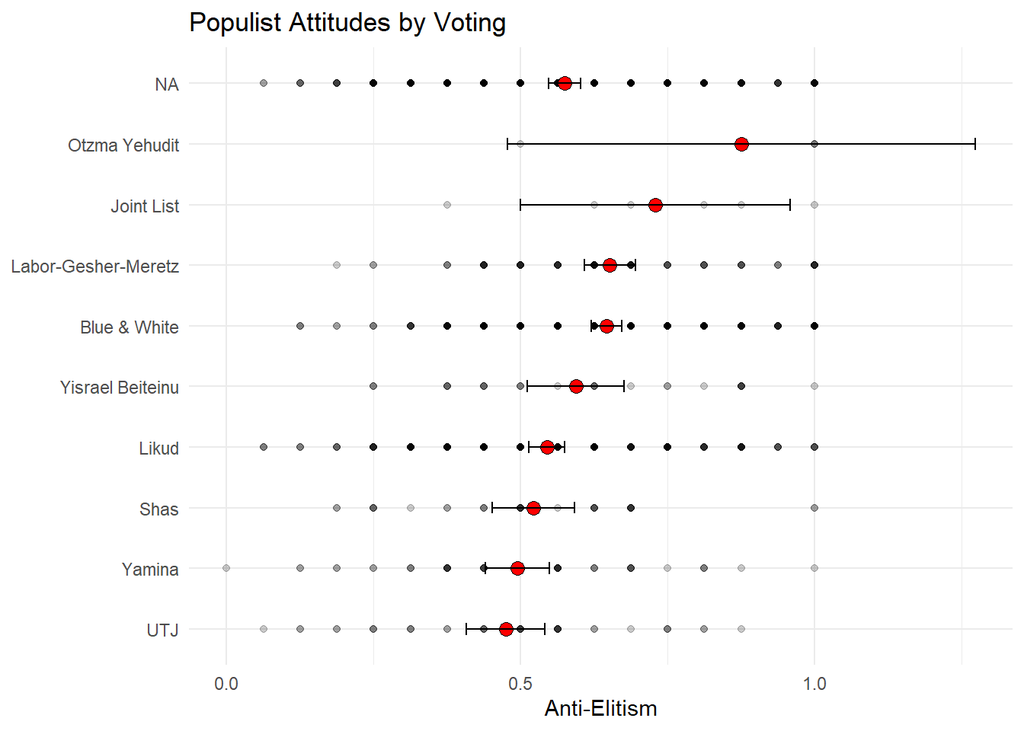

```r
cses_isr %>%
  group_by(voting) %>%
  mutate(mean_pop = mean(anti_elitism, na.rm = T)) %>%
  ungroup() %>%
  mutate(voting = fct_reorder(voting, mean_pop)) %>%
  ggplot(aes(x = voting, y = anti_elitism)) +
  geom_point(alpha = 0.2) +
  stat_summary(fun = mean, geom = "point", shape = 21, size = 3, fill = "red", color = "black") +
    stat_summary(fun.data = mean_cl_normal, geom = "errorbar", width = 0.2) +
coord_flip() +
  labs(x = NULL,
       y = "Anti-Elitism",
       title = "Populist Attitudes by Voting") +
  theme_minimal()
```

## **Populist Attitudes Index (3-dim) and Voting**

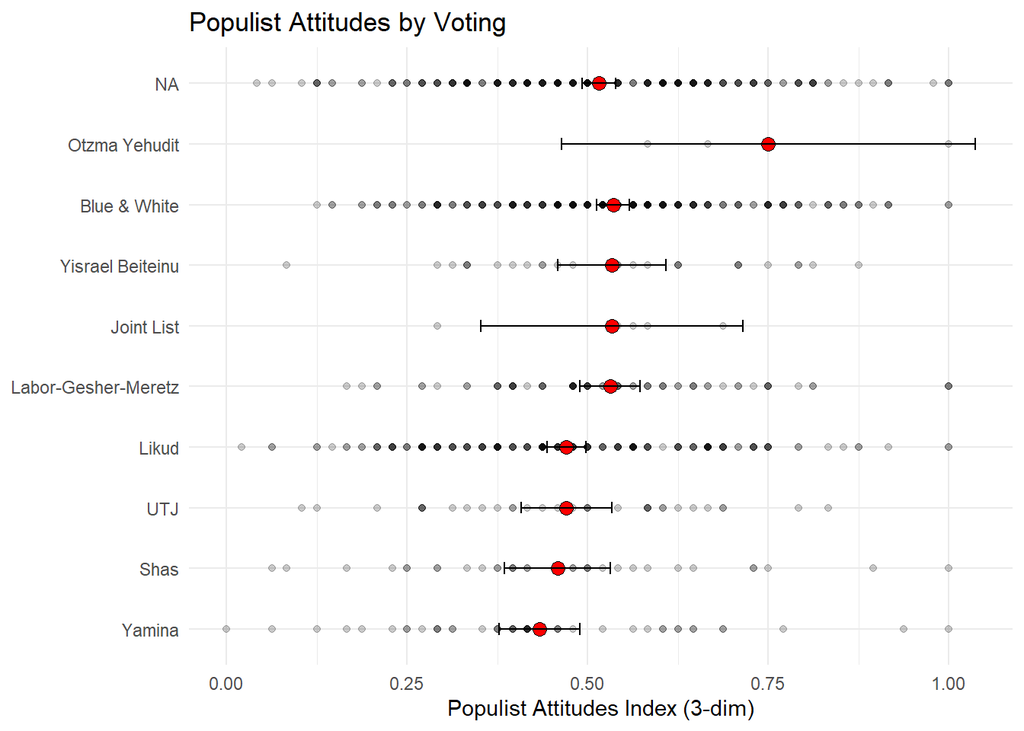

```r
cses_isr %>%
  group_by(voting) %>%
  mutate(mean_pop = mean(populist_attitudes_idx_3dim, na.rm = T)) %>%
  ungroup() %>%
  mutate(voting = fct_reorder(voting, mean_pop)) %>%
  ggplot(aes(x = voting, y = populist_attitudes_idx_3dim)) +
  geom_point(alpha = 0.2) +
  stat_summary(fun = mean, geom = "point", shape = 21, size = 3, fill = "red", color = "black") +
    stat_summary(fun.data = mean_cl_normal, geom = "errorbar", width = 0.2) +
coord_flip() +
  labs(x = NULL,
       y = "Populist Attitudes Index (3-dim)",
       title = "Populist Attitudes by Voting") +
  theme_minimal()
```

## **Histogram: Anti-Elitism**

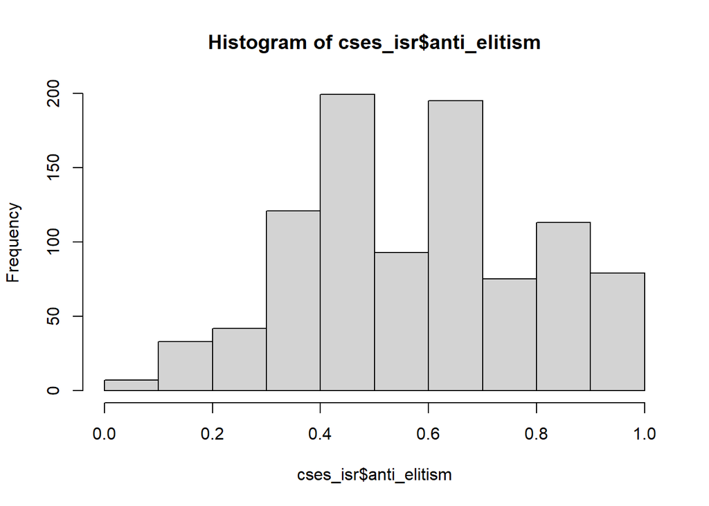

```r
hist(cses_isr $ anti_elitism)
```

## **Histogram: Popular Sovereignty**

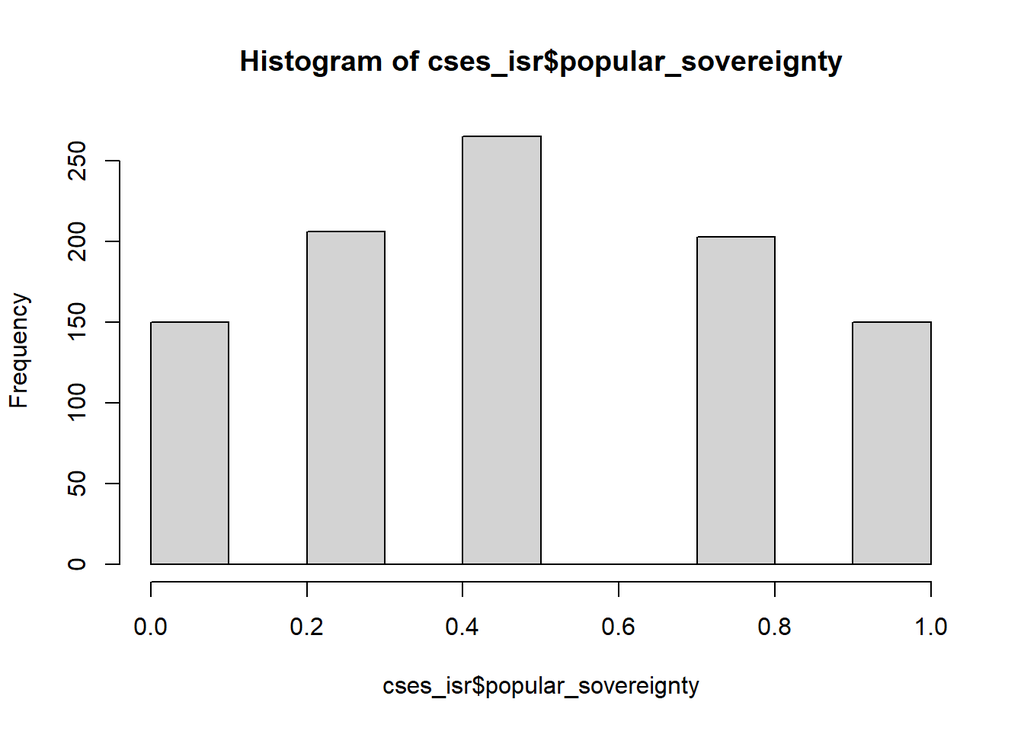

```r
hist(cses_isr $ popular_sovereignty)
```

## **Histogram: Manichean**

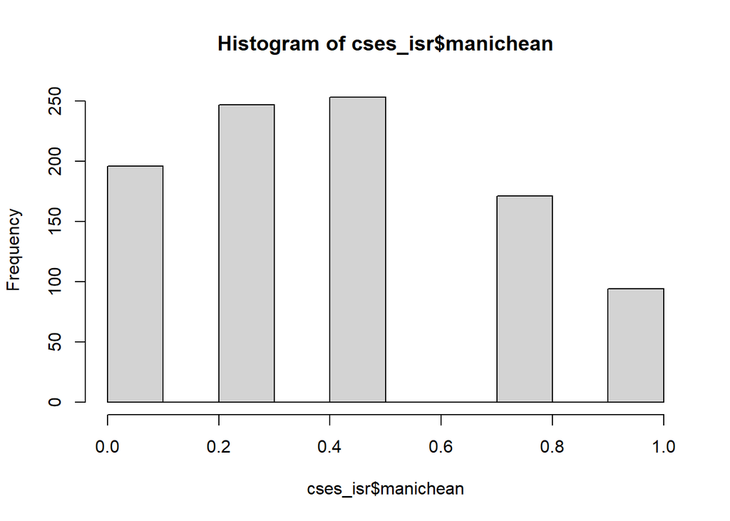

```r
hist(cses_isr $ manichean)
```

## **Histogram: Populist Attitudes Index 3-dim**

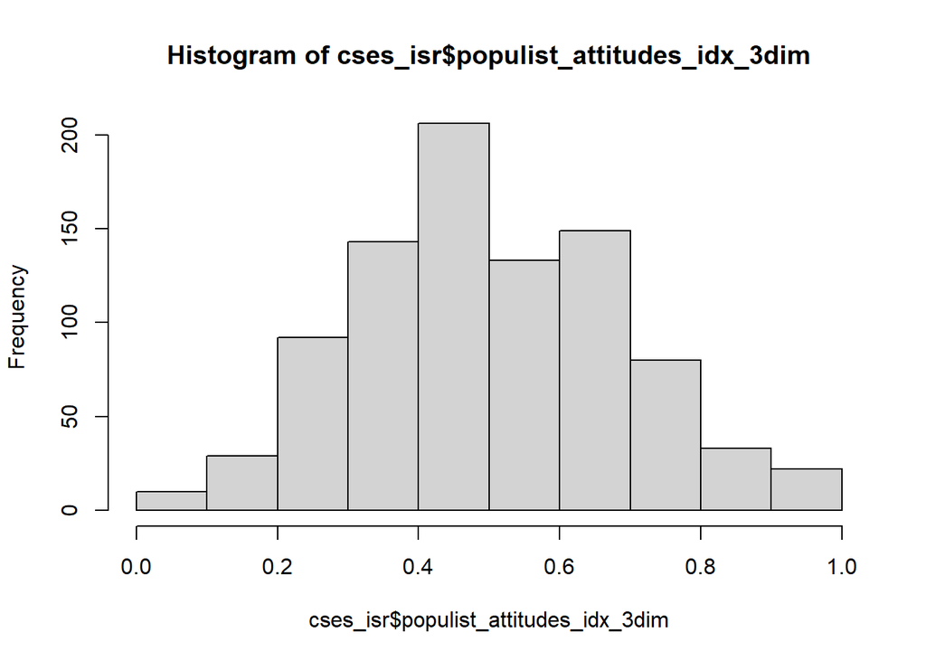

```r
hist(cses_isr $ populist_attitudes_idx_3dim)
```